# Администрирование сетевых подсистем

Настройка и анализ работы DNS-сервера BIND

Сейдалиев Тагиетдин Ровшенович

Российский университет дружбы народов, Москва, Россия

19 ноября 2025

# Цель работы

## Основная цель

Освоить установку, конфигурирование и анализ работы DNS-сервера BIND,  
а также автоматизацию его настройки во внутреннем окружении ВМ.

# Установка DNS-сервера

## Проверка работы внешнего DNS

- Установлены пакеты bind и bind-utils
- Выполнен тест dig для внешнего DNS
- Проанализирована структура DNS-ответа

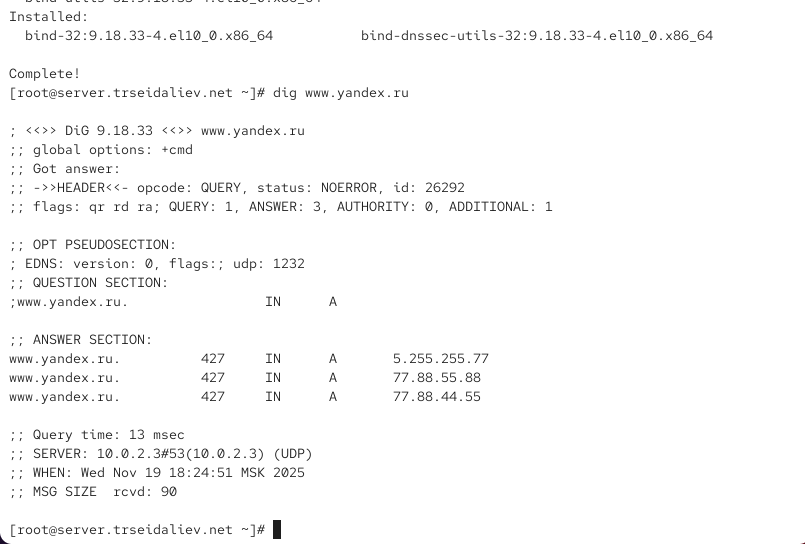

dig внешний DNS

# Конфигурирование кэширующего DNS

## Конфигурация resolv.conf и named.conf

- Использование внешнего nameserver
- Настройки listen-on и allow-query
- Структура служебных файлов

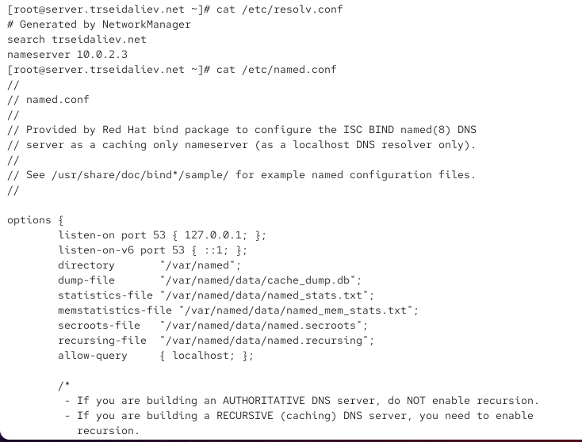

named.conf

## Файлы корневых и локальных зон

- named.ca — корневые DNS-серверы
- named.localhost — локальная зона
- named.loopback — обратная зона

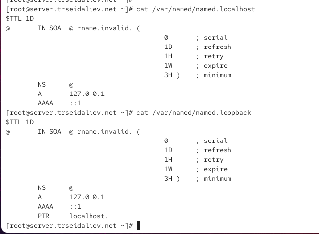

root и local zone

# Проверка работы локального DNS

## dig через 127.0.0.1

- Корректный ответ сервера
- Работает кэширование запросов

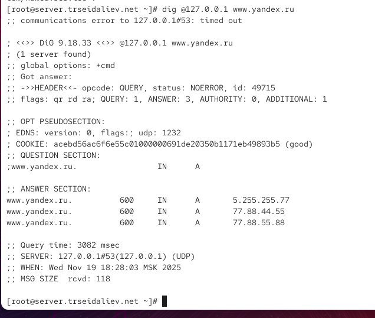

dig 127.0.0.1

## Настройка DNS через nmcli

- Включён ignore-auto-dns
- Установлен DNS = 127.0.0.1
- resolv.conf обновлён

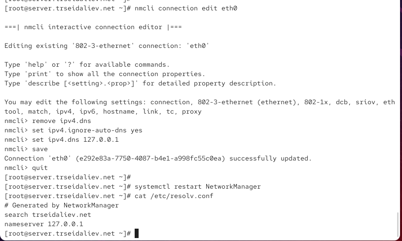

nmcli настройка

# Настройка доступа сети

## Правки named.conf

- Прослушивание на всех интерфейсах
- Разрешение запросов от сети 192.168.0.0/16

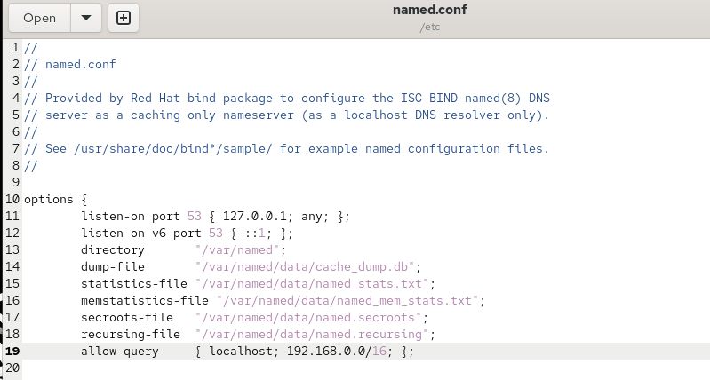

listen/allow-query

## Настройка firewall и проверка порта

- Открыт порт 53 TCP/UDP
- named слушает порт корректно

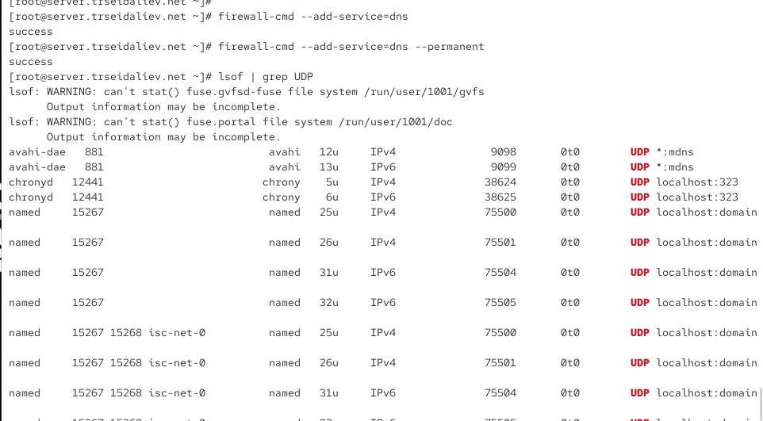

lsof порт 53

# Настройка первичного DNS-сервера

## Подключение файла зон

- Скопирован шаблон зон
- Добавлен include для файла trseidalev.net

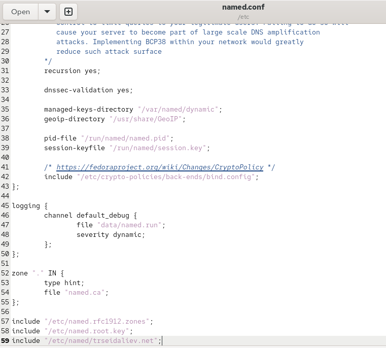

include зоны

## Прямая и обратная зона

- Создана зона trseidalev.net
- Создана обратная зона 1.168.192.in-addr.arpa

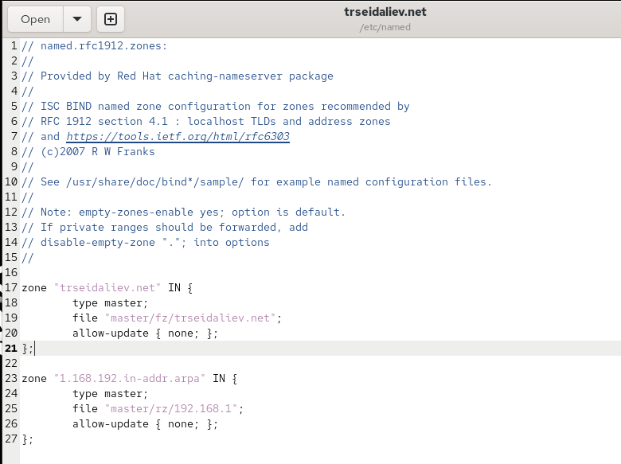

zone файлы

# Файлы мастер-зон

## Прямая зона

- SOA-запись
- NS и A-записи
- $ORIGIN trseidalev.net.

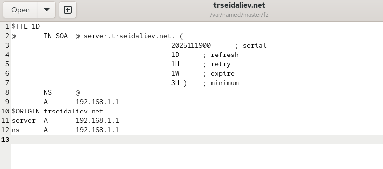

fz зона

## Обратная зона

- PTR-записи
- Корректный SOA
- Соответствие IP ↔︎ имя

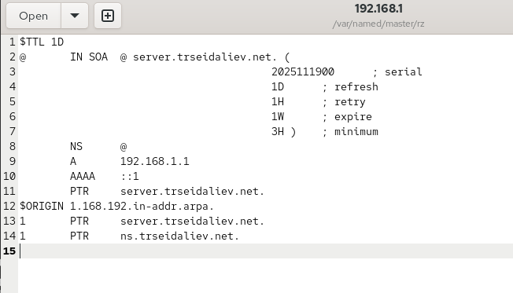

rz зона

# SELinux и права

## Настройка SELinux

- Восстановлены контексты
- Разрешена запись в мастер-зоны
- Проверены bool-переключатели

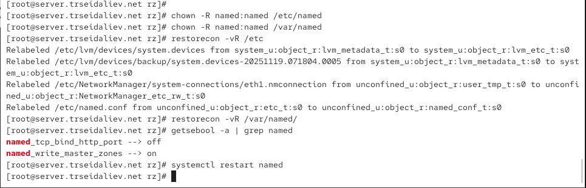

selinux вывод

# Анализ работы DNS

## Проверка dig

- ns.trseidalev.net → 192.168.1.1
- Корректная A-запись

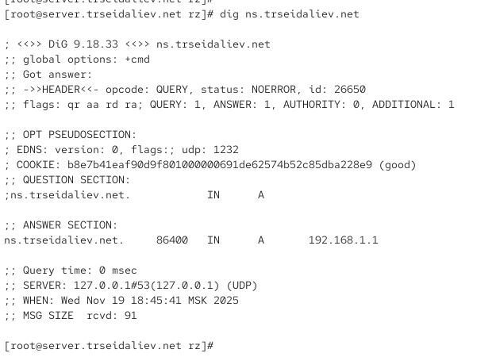

dig ns.trseidalev.net

## Проверка host

- Листинг зоны
- ANY-запросы
- PTR-записи

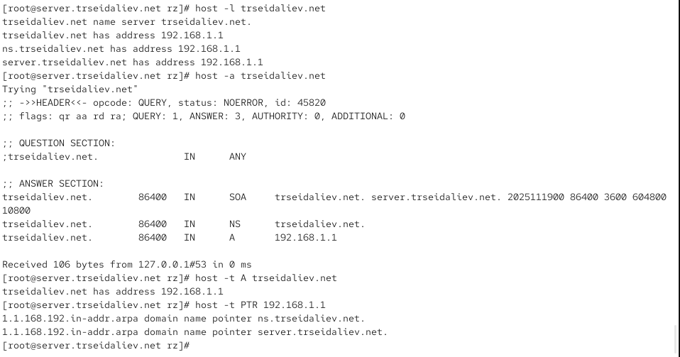

host проверки

# Итоги работы